# Risk Factor Analysis

## Outcome Variable

**Outcome Variable:** y_rate_len

## Predictor Variables

**Intervention Variable:** impsan

**Adjustment Set:**

unadjusted

## Stratifying Variables

The analysis was stratified on these variable(s):

- agecat
- studyid
- country

## Data Summary

| agecat | studyid | country | impsan | n_cell | n |
| --- | --- | --- | --- | --- | --- |
| 0-3 months | ki0047075b-MAL-ED | BANGLADESH | 0 | 38 | 237 |
| 0-3 months | ki0047075b-MAL-ED | BANGLADESH | 1 | 199 | 237 |
| 0-3 months | ki0047075b-MAL-ED | BRAZIL | 0 | 4 | 174 |
| 0-3 months | ki0047075b-MAL-ED | BRAZIL | 1 | 170 | 174 |
| 0-3 months | ki0047075b-MAL-ED | INDIA | 0 | 101 | 193 |
| 0-3 months | ki0047075b-MAL-ED | INDIA | 1 | 92 | 193 |
| 0-3 months | ki0047075b-MAL-ED | NEPAL | 0 | 1 | 174 |
| 0-3 months | ki0047075b-MAL-ED | NEPAL | 1 | 173 | 174 |
| 0-3 months | ki0047075b-MAL-ED | PERU | 0 | 190 | 252 |
| 0-3 months | ki0047075b-MAL-ED | PERU | 1 | 62 | 252 |
| 0-3 months | ki0047075b-MAL-ED | SOUTH AFRICA | 0 | 209 | 211 |
| 0-3 months | ki0047075b-MAL-ED | SOUTH AFRICA | 1 | 2 | 211 |
| 0-3 months | ki0047075b-MAL-ED | TANZANIA, UNITED REPUBLIC OF | 0 | 217 | 217 |
| 0-3 months | ki0047075b-MAL-ED | TANZANIA, UNITED REPUBLIC OF | 1 | 0 | 217 |
| 0-3 months | ki1017093-NIH-Birth | BANGLADESH | 0 | 348 | 566 |
| 0-3 months | ki1017093-NIH-Birth | BANGLADESH | 1 | 218 | 566 |
| 0-3 months | ki1017093b-PROVIDE | BANGLADESH | 0 | 29 | 634 |
| 0-3 months | ki1017093b-PROVIDE | BANGLADESH | 1 | 605 | 634 |
| 0-3 months | ki1017093c-NIH-Crypto | BANGLADESH | 0 | 84 | 709 |
| 0-3 months | ki1017093c-NIH-Crypto | BANGLADESH | 1 | 625 | 709 |
| 0-3 months | ki1114097-CONTENT | PERU | 0 | 4 | 29 |
| 0-3 months | ki1114097-CONTENT | PERU | 1 | 25 | 29 |
| 0-3 months | ki1135781-COHORTS | GUATEMALA | 0 | 403 | 445 |
| 0-3 months | ki1135781-COHORTS | GUATEMALA | 1 | 42 | 445 |
| 0-3 months | ki1135781-COHORTS | INDIA | 0 | 2928 | 4660 |
| 0-3 months | ki1135781-COHORTS | INDIA | 1 | 1732 | 4660 |
| 0-3 months | kiGH5241-JiVitA-3 | BANGLADESH | 0 | 12644 | 40056 |
| 0-3 months | kiGH5241-JiVitA-3 | BANGLADESH | 1 | 27412 | 40056 |
| 0-3 months | kiGH5241-JiVitA-4 | BANGLADESH | 0 | 814 | 3610 |
| 0-3 months | kiGH5241-JiVitA-4 | BANGLADESH | 1 | 2796 | 3610 |

[output cut: 98 more lines]

The following strata were considered:

- agecat: 0-3 months, studyid: ki0047075b-MAL-ED, country: BANGLADESH
- agecat: 0-3 months, studyid: ki0047075b-MAL-ED, country: BRAZIL
- agecat: 0-3 months, studyid: ki0047075b-MAL-ED, country: INDIA
- agecat: 0-3 months, studyid: ki0047075b-MAL-ED, country: NEPAL
- agecat: 0-3 months, studyid: ki0047075b-MAL-ED, country: PERU
- agecat: 0-3 months, studyid: ki0047075b-MAL-ED, country: SOUTH AFRICA
- agecat: 0-3 months, studyid: ki0047075b-MAL-ED, country: TANZANIA, UNITED REPUBLIC OF
- agecat: 0-3 months, studyid: ki1017093-NIH-Birth, country: BANGLADESH
- agecat: 0-3 months, studyid: ki1017093b-PROVIDE, country: BANGLADESH
- agecat: 0-3 months, studyid: ki1017093c-NIH-Crypto, country: BANGLADESH
- agecat: 0-3 months, studyid: ki1114097-CONTENT, country: PERU
- agecat: 0-3 months, studyid: ki1135781-COHORTS, country: GUATEMALA
- agecat: 0-3 months, studyid: ki1135781-COHORTS, country: INDIA
- agecat: 0-3 months, studyid: kiGH5241-JiVitA-3, country: BANGLADESH
- agecat: 0-3 months, studyid: kiGH5241-JiVitA-4, country: BANGLADESH
- agecat: 12-24 months, studyid: ki0047075b-MAL-ED, country: BANGLADESH
- agecat: 12-24 months, studyid: ki0047075b-MAL-ED, country: BRAZIL
- agecat: 12-24 months, studyid: ki0047075b-MAL-ED, country: INDIA
- agecat: 12-24 months, studyid: ki0047075b-MAL-ED, country: NEPAL
- agecat: 12-24 months, studyid: ki0047075b-MAL-ED, country: PERU
- agecat: 12-24 months, studyid: ki0047075b-MAL-ED, country: SOUTH AFRICA
- agecat: 12-24 months, studyid: ki0047075b-MAL-ED, country: TANZANIA, UNITED REPUBLIC OF
- agecat: 12-24 months, studyid: ki1017093-NIH-Birth, country: BANGLADESH
- agecat: 12-24 months, studyid: ki1017093b-PROVIDE, country: BANGLADESH
- agecat: 12-24 months, studyid: ki1017093c-NIH-Crypto, country: BANGLADESH
- agecat: 12-24 months, studyid: ki1114097-CONTENT, country: PERU
- agecat: 12-24 months, studyid: ki1135781-COHORTS, country: GUATEMALA
- agecat: 12-24 months, studyid: ki1135781-COHORTS, country: INDIA
- agecat: 12-24 months, studyid: ki1135781-COHORTS, country: PHILIPPINES
- agecat: 12-24 months, studyid: ki1148112-LCNI-5, country: MALAWI
- agecat: 12-24 months, studyid: kiGH5241-JiVitA-3, country: BANGLADESH
- agecat: 12-24 months, studyid: kiGH5241-JiVitA-4, country: BANGLADESH
- agecat: 3-6 months, studyid: ki0047075b-MAL-ED, country: BANGLADESH
- agecat: 3-6 months, studyid: ki0047075b-MAL-ED, country: BRAZIL
- agecat: 3-6 months, studyid: ki0047075b-MAL-ED, country: INDIA
- agecat: 3-6 months, studyid: ki0047075b-MAL-ED, country: NEPAL
- agecat: 3-6 months, studyid: ki0047075b-MAL-ED, country: PERU
- agecat: 3-6 months, studyid: ki0047075b-MAL-ED, country: SOUTH AFRICA
- agecat: 3-6 months, studyid: ki0047075b-MAL-ED, country: TANZANIA, UNITED REPUBLIC OF
- agecat: 3-6 months, studyid: ki1017093-NIH-Birth, country: BANGLADESH
- agecat: 3-6 months, studyid: ki1017093b-PROVIDE, country: BANGLADESH
- agecat: 3-6 months, studyid: ki1017093c-NIH-Crypto, country: BANGLADESH
- agecat: 3-6 months, studyid: ki1114097-CONTENT, country: PERU
- agecat: 3-6 months, studyid: ki1135781-COHORTS, country: GUATEMALA
- agecat: 3-6 months, studyid: ki1135781-COHORTS, country: INDIA
- agecat: 3-6 months, studyid: kiGH5241-JiVitA-3, country: BANGLADESH
- agecat: 3-6 months, studyid: kiGH5241-JiVitA-4, country: BANGLADESH
- agecat: 6-12 months, studyid: ki0047075b-MAL-ED, country: BANGLADESH
- agecat: 6-12 months, studyid: ki0047075b-MAL-ED, country: BRAZIL
- agecat: 6-12 months, studyid: ki0047075b-MAL-ED, country: INDIA
- agecat: 6-12 months, studyid: ki0047075b-MAL-ED, country: NEPAL
- agecat: 6-12 months, studyid: ki0047075b-MAL-ED, country: PERU
- agecat: 6-12 months, studyid: ki0047075b-MAL-ED, country: SOUTH AFRICA
- agecat: 6-12 months, studyid: ki0047075b-MAL-ED, country: TANZANIA, UNITED REPUBLIC OF
- agecat: 6-12 months, studyid: ki1017093-NIH-Birth, country: BANGLADESH
- agecat: 6-12 months, studyid: ki1017093b-PROVIDE, country: BANGLADESH
- agecat: 6-12 months, studyid: ki1017093c-NIH-Crypto, country: BANGLADESH
- agecat: 6-12 months, studyid: ki1114097-CONTENT, country: PERU
- agecat: 6-12 months, studyid: ki1135781-COHORTS, country: GUATEMALA
- agecat: 6-12 months, studyid: ki1135781-COHORTS, country: INDIA
- agecat: 6-12 months, studyid: ki1135781-COHORTS, country: PHILIPPINES
- agecat: 6-12 months, studyid: ki1148112-LCNI-5, country: MALAWI
- agecat: 6-12 months, studyid: kiGH5241-JiVitA-3, country: BANGLADESH
- agecat: 6-12 months, studyid: kiGH5241-JiVitA-4, country: BANGLADESH

### Dropped Strata

Some strata were dropped due to rare outcomes:

- agecat: 0-3 months, studyid: ki0047075b-MAL-ED, country: BRAZIL
- agecat: 0-3 months, studyid: ki0047075b-MAL-ED, country: NEPAL
- agecat: 0-3 months, studyid: ki0047075b-MAL-ED, country: SOUTH AFRICA
- agecat: 0-3 months, studyid: ki0047075b-MAL-ED, country: TANZANIA, UNITED REPUBLIC OF
- agecat: 0-3 months, studyid: ki1114097-CONTENT, country: PERU
- agecat: 3-6 months, studyid: ki0047075b-MAL-ED, country: BRAZIL
- agecat: 3-6 months, studyid: ki0047075b-MAL-ED, country: NEPAL
- agecat: 3-6 months, studyid: ki0047075b-MAL-ED, country: SOUTH AFRICA
- agecat: 3-6 months, studyid: ki0047075b-MAL-ED, country: TANZANIA, UNITED REPUBLIC OF
- agecat: 6-12 months, studyid: ki0047075b-MAL-ED, country: BRAZIL
- agecat: 6-12 months, studyid: ki0047075b-MAL-ED, country: NEPAL
- agecat: 6-12 months, studyid: ki0047075b-MAL-ED, country: SOUTH AFRICA
- agecat: 6-12 months, studyid: ki0047075b-MAL-ED, country: TANZANIA, UNITED REPUBLIC OF
- agecat: 6-12 months, studyid: ki1148112-LCNI-5, country: MALAWI
- agecat: 12-24 months, studyid: ki0047075b-MAL-ED, country: BRAZIL
- agecat: 12-24 months, studyid: ki0047075b-MAL-ED, country: NEPAL
- agecat: 12-24 months, studyid: ki0047075b-MAL-ED, country: SOUTH AFRICA
- agecat: 12-24 months, studyid: ki0047075b-MAL-ED, country: TANZANIA, UNITED REPUBLIC OF
- agecat: 12-24 months, studyid: ki1114097-CONTENT, country: PERU
- agecat: 12-24 months, studyid: ki1148112-LCNI-5, country: MALAWI

## Methods Detail

We’re interested in the causal parameters $E[Y_a]$ for all values of $a \in \mathcal{A}$. These parameters represent the mean outcome if, possibly contrary to fact, we intervened to set all units to have $A=a$. Under the randomization and positivity assumptions, these are identified by the statistical parameters $\psi_a=E_W[E_{Y|A,W}(Y|A=a,W)]$. In addition, we’re interested in the mean of $Y$, $E[Y]$ under no intervention (the observed mean). We will estimate these parameters by using SuperLearner to fit the relevant likelihood factors – $E_{Y|A,W}(Y|A=a,W)$ and $p(A=a|W)$, and then updating our likelihood fit using a joint TMLE.

For unadjusted analyses ($W=\{\}$), initial likelihoods were estimated using Lrnr_glm to estimate the simple $E(Y|A)$ and Lrnr_mean to estimate $p(A)$. For adjusted analyses, a small library containing Lrnr_glmnet, Lrnr_xgboost, and Lrnr_mean was used.

Having estimated these parameters, we will then use the delta method to estimate relative risks and attributable risks relative to a prespecified baseline level of $A$.

# Results Detail

## Results Plots

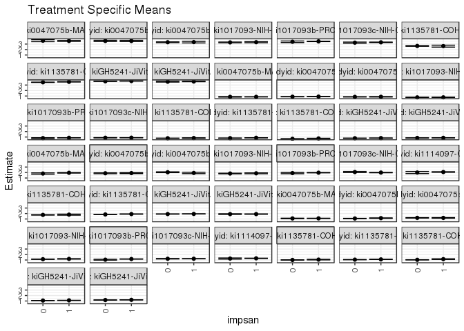

[figure not shown]

## Results Table

### Parameter: TSM

| agecat | studyid | country | intervention_level | baseline_level | estimate | ci_lower | ci_upper |
| --- | --- | --- | --- | --- | --- | --- | --- |
| 0-3 months | ki0047075b-MAL-ED | BANGLADESH | 0 | NA | 3.6146776 | 3.4329889 | 3.7963662 |
| 0-3 months | ki0047075b-MAL-ED | BANGLADESH | 1 | NA | 3.5633488 | 3.4968095 | 3.6298881 |
| 0-3 months | ki0047075b-MAL-ED | INDIA | 0 | NA | 3.5686613 | 3.4598261 | 3.6774965 |
| 0-3 months | ki0047075b-MAL-ED | INDIA | 1 | NA | 3.5581551 | 3.4500301 | 3.6662801 |
| 0-3 months | ki0047075b-MAL-ED | PERU | 0 | NA | 3.3303252 | 3.2595055 | 3.4011449 |
| 0-3 months | ki0047075b-MAL-ED | PERU | 1 | NA | 3.3524765 | 3.2091310 | 3.4958219 |
| 0-3 months | ki1017093-NIH-Birth | BANGLADESH | 0 | NA | 3.2990840 | 3.2324405 | 3.3657275 |
| 0-3 months | ki1017093-NIH-Birth | BANGLADESH | 1 | NA | 3.3350210 | 3.2406401 | 3.4294019 |
| 0-3 months | ki1017093b-PROVIDE | BANGLADESH | 0 | NA | 3.4135306 | 3.2658982 | 3.5611630 |
| 0-3 months | ki1017093b-PROVIDE | BANGLADESH | 1 | NA | 3.4859847 | 3.4455565 | 3.5264130 |
| 0-3 months | ki1017093c-NIH-Crypto | BANGLADESH | 0 | NA | 3.2550506 | 3.1543877 | 3.3557135 |
| 0-3 months | ki1017093c-NIH-Crypto | BANGLADESH | 1 | NA | 3.3134525 | 3.2720014 | 3.3549036 |
| 0-3 months | ki1135781-COHORTS | GUATEMALA | 0 | NA | 2.6498928 | 2.5918960 | 2.7078896 |
| 0-3 months | ki1135781-COHORTS | GUATEMALA | 1 | NA | 2.6189067 | 2.4395843 | 2.7982291 |
| 0-3 months | ki1135781-COHORTS | INDIA | 0 | NA | 3.5001136 | 3.4787205 | 3.5215066 |
| 0-3 months | ki1135781-COHORTS | INDIA | 1 | NA | 3.5875823 | 3.5603464 | 3.6148181 |
| 0-3 months | kiGH5241-JiVitA-3 | BANGLADESH | 0 | NA | 3.6863250 | 3.6697528 | 3.7028972 |
| 0-3 months | kiGH5241-JiVitA-3 | BANGLADESH | 1 | NA | 3.7332320 | 3.7215925 | 3.7448714 |
| 0-3 months | kiGH5241-JiVitA-4 | BANGLADESH | 0 | NA | 3.6122761 | 3.5458499 | 3.6787023 |
| 0-3 months | kiGH5241-JiVitA-4 | BANGLADESH | 1 | NA | 3.6462866 | 3.6107893 | 3.6817838 |
| 3-6 months | ki0047075b-MAL-ED | BANGLADESH | 0 | NA | 1.8165982 | 1.7021017 | 1.9310947 |
| 3-6 months | ki0047075b-MAL-ED | BANGLADESH | 1 | NA | 1.9499893 | 1.8960058 | 2.0039728 |
| 3-6 months | ki0047075b-MAL-ED | INDIA | 0 | NA | 1.8643717 | 1.7815779 | 1.9471654 |
| 3-6 months | ki0047075b-MAL-ED | INDIA | 1 | NA | 1.8953711 | 1.8060981 | 1.9846440 |
| 3-6 months | ki0047075b-MAL-ED | PERU | 0 | NA | 2.0521496 | 1.9764783 | 2.1278209 |
| 3-6 months | ki0047075b-MAL-ED | PERU | 1 | NA | 1.9206171 | 1.7899784 | 2.0512559 |
| 3-6 months | ki1017093-NIH-Birth | BANGLADESH | 0 | NA | 1.8189448 | 1.7602643 | 1.8776254 |
| 3-6 months | ki1017093-NIH-Birth | BANGLADESH | 1 | NA | 1.8552555 | 1.7728284 | 1.9376825 |
| 3-6 months | ki1017093b-PROVIDE | BANGLADESH | 0 | NA | 1.8974301 | 1.7793713 | 2.0154889 |
| 3-6 months | ki1017093b-PROVIDE | BANGLADESH | 1 | NA | 1.9694929 | 1.9331893 | 2.0057965 |

[output cut: 58 more lines]

### Parameter: E(Y)

| agecat | studyid | country | intervention_level | baseline_level | estimate | ci_lower | ci_upper |
| --- | --- | --- | --- | --- | --- | --- | --- |
| 0-3 months | ki0047075b-MAL-ED | BANGLADESH | NA | NA | 3.5715787 | 3.5085237 | 3.6346338 |
| 0-3 months | ki0047075b-MAL-ED | INDIA | NA | NA | 3.5636532 | 3.4868354 | 3.6404709 |
| 0-3 months | ki0047075b-MAL-ED | PERU | NA | NA | 3.3357751 | 3.2717728 | 3.3997775 |
| 0-3 months | ki1017093-NIH-Birth | BANGLADESH | NA | NA | 3.3129255 | 3.2581305 | 3.3677204 |
| 0-3 months | ki1017093b-PROVIDE | BANGLADESH | NA | NA | 3.4826706 | 3.4434873 | 3.5218539 |
| 0-3 months | ki1017093c-NIH-Crypto | BANGLADESH | NA | NA | 3.3065332 | 3.2680709 | 3.3449955 |
| 0-3 months | ki1135781-COHORTS | GUATEMALA | NA | NA | 2.6469683 | 2.5917793 | 2.7021572 |
| 0-3 months | ki1135781-COHORTS | INDIA | NA | NA | 3.5326234 | 3.5157525 | 3.5494943 |
| 0-3 months | kiGH5241-JiVitA-3 | BANGLADESH | NA | NA | 3.7184254 | 3.7080855 | 3.7287653 |
| 0-3 months | kiGH5241-JiVitA-4 | BANGLADESH | NA | NA | 3.6386177 | 3.6075243 | 3.6697112 |
| 3-6 months | ki0047075b-MAL-ED | BANGLADESH | NA | NA | 1.9280462 | 1.8787523 | 1.9773401 |
| 3-6 months | ki0047075b-MAL-ED | INDIA | NA | NA | 1.8786477 | 1.8179085 | 1.9393869 |
| 3-6 months | ki0047075b-MAL-ED | PERU | NA | NA | 2.0202782 | 1.9544261 | 2.0861304 |
| 3-6 months | ki1017093-NIH-Birth | BANGLADESH | NA | NA | 1.8326915 | 1.7846731 | 1.8807099 |
| 3-6 months | ki1017093b-PROVIDE | BANGLADESH | NA | NA | 1.9662173 | 1.9311292 | 2.0013054 |
| 3-6 months | ki1017093c-NIH-Crypto | BANGLADESH | NA | NA | 2.0027540 | 1.9667312 | 2.0387768 |
| 3-6 months | ki1114097-CONTENT | PERU | NA | NA | 2.0841841 | 2.0362519 | 2.1321163 |
| 3-6 months | ki1135781-COHORTS | GUATEMALA | NA | NA | 1.7541195 | 1.7166655 | 1.7915734 |
| 3-6 months | ki1135781-COHORTS | INDIA | NA | NA | 1.8572103 | 1.8432112 | 1.8712094 |
| 3-6 months | kiGH5241-JiVitA-3 | BANGLADESH | NA | NA | 1.9202048 | 1.9097374 | 1.9306722 |
| 3-6 months | kiGH5241-JiVitA-4 | BANGLADESH | NA | NA | 1.8987567 | 1.8688242 | 1.9286892 |
| 6-12 months | ki0047075b-MAL-ED | BANGLADESH | NA | NA | 1.1143928 | 1.0896103 | 1.1391753 |
| 6-12 months | ki0047075b-MAL-ED | INDIA | NA | NA | 1.1214380 | 1.0928994 | 1.1499767 |
| 6-12 months | ki0047075b-MAL-ED | PERU | NA | NA | 1.2081918 | 1.1749797 | 1.2414040 |
| 6-12 months | ki1017093-NIH-Birth | BANGLADESH | NA | NA | 1.1679344 | 1.1454934 | 1.1903754 |
| 6-12 months | ki1017093b-PROVIDE | BANGLADESH | NA | NA | 1.1737150 | 1.1564064 | 1.1910236 |
| 6-12 months | ki1017093c-NIH-Crypto | BANGLADESH | NA | NA | 1.2296139 | 1.2120656 | 1.2471621 |
| 6-12 months | ki1114097-CONTENT | PERU | NA | NA | 1.3010517 | 1.2719491 | 1.3301542 |
| 6-12 months | ki1135781-COHORTS | GUATEMALA | NA | NA | 1.0143216 | 0.9941032 | 1.0345401 |
| 6-12 months | ki1135781-COHORTS | INDIA | NA | NA | 1.0832753 | 1.0736142 | 1.0929363 |
| 6-12 months | ki1135781-COHORTS | PHILIPPINES | NA | NA | 1.0498206 | 1.0308068 | 1.0688345 |
| 6-12 months | kiGH5241-JiVitA-3 | BANGLADESH | NA | NA | 1.1069118 | 1.1001686 | 1.1136550 |
| 6-12 months | kiGH5241-JiVitA-4 | BANGLADESH | NA | NA | 1.2031561 | 1.1927695 | 1.2135427 |
| 12-24 months | ki0047075b-MAL-ED | BANGLADESH | NA | NA | 0.8459764 | 0.8299714 | 0.8619814 |
| 12-24 months | ki0047075b-MAL-ED | INDIA | NA | NA | 0.8815607 | 0.8644247 | 0.8986966 |
| 12-24 months | ki0047075b-MAL-ED | PERU | NA | NA | 0.8469084 | 0.8260658 | 0.8677509 |
| 12-24 months | ki1017093-NIH-Birth | BANGLADESH | NA | NA | 0.7513013 | 0.7366996 | 0.7659029 |
| 12-24 months | ki1017093b-PROVIDE | BANGLADESH | NA | NA | 0.8575399 | 0.8455203 | 0.8695594 |
| 12-24 months | ki1017093c-NIH-Crypto | BANGLADESH | NA | NA | 0.8757546 | 0.8638195 | 0.8876896 |
| 12-24 months | ki1135781-COHORTS | GUATEMALA | NA | NA | 0.7787104 | 0.7669110 | 0.7905098 |
| 12-24 months | ki1135781-COHORTS | INDIA | NA | NA | 0.8192911 | 0.8134060 | 0.8251761 |
| 12-24 months | ki1135781-COHORTS | PHILIPPINES | NA | NA | 0.6772522 | 0.6655435 | 0.6889610 |
| 12-24 months | kiGH5241-JiVitA-3 | BANGLADESH | NA | NA | 0.7965889 | 0.7912788 | 0.8018990 |
| 12-24 months | kiGH5241-JiVitA-4 | BANGLADESH | NA | NA | 0.8492623 | 0.8438054 | 0.8547191 |

### Parameter: ATE

| agecat | studyid | country | intervention_level | baseline_level | estimate | ci_lower | ci_upper |
| --- | --- | --- | --- | --- | --- | --- | --- |
| 0-3 months | ki0047075b-MAL-ED | BANGLADESH | 0 | 0 | 0.0000000 | 0.0000000 | 0.0000000 |
| 0-3 months | ki0047075b-MAL-ED | BANGLADESH | 1 | 0 | -0.0513288 | -0.2448184 | 0.1421609 |
| 0-3 months | ki0047075b-MAL-ED | INDIA | 0 | 0 | 0.0000000 | 0.0000000 | 0.0000000 |
| 0-3 months | ki0047075b-MAL-ED | INDIA | 1 | 0 | -0.0105062 | -0.1639211 | 0.1429087 |
| 0-3 months | ki0047075b-MAL-ED | PERU | 0 | 0 | 0.0000000 | 0.0000000 | 0.0000000 |
| 0-3 months | ki0047075b-MAL-ED | PERU | 1 | 0 | 0.0221512 | -0.1377342 | 0.1820366 |
| 0-3 months | ki1017093-NIH-Birth | BANGLADESH | 0 | 0 | 0.0000000 | 0.0000000 | 0.0000000 |
| 0-3 months | ki1017093-NIH-Birth | BANGLADESH | 1 | 0 | 0.0359370 | -0.0796014 | 0.1514754 |
| 0-3 months | ki1017093b-PROVIDE | BANGLADESH | 0 | 0 | 0.0000000 | 0.0000000 | 0.0000000 |
| 0-3 months | ki1017093b-PROVIDE | BANGLADESH | 1 | 0 | 0.0724541 | -0.0806137 | 0.2255220 |
| 0-3 months | ki1017093c-NIH-Crypto | BANGLADESH | 0 | 0 | 0.0000000 | 0.0000000 | 0.0000000 |
| 0-3 months | ki1017093c-NIH-Crypto | BANGLADESH | 1 | 0 | 0.0584019 | -0.0504613 | 0.1672652 |
| 0-3 months | ki1135781-COHORTS | GUATEMALA | 0 | 0 | 0.0000000 | 0.0000000 | 0.0000000 |
| 0-3 months | ki1135781-COHORTS | GUATEMALA | 1 | 0 | -0.0309861 | -0.2194540 | 0.1574819 |
| 0-3 months | ki1135781-COHORTS | INDIA | 0 | 0 | 0.0000000 | 0.0000000 | 0.0000000 |
| 0-3 months | ki1135781-COHORTS | INDIA | 1 | 0 | 0.0874687 | 0.0528356 | 0.1221018 |
| 0-3 months | kiGH5241-JiVitA-3 | BANGLADESH | 0 | 0 | 0.0000000 | 0.0000000 | 0.0000000 |
| 0-3 months | kiGH5241-JiVitA-3 | BANGLADESH | 1 | 0 | 0.0469070 | 0.0284577 | 0.0653562 |
| 0-3 months | kiGH5241-JiVitA-4 | BANGLADESH | 0 | 0 | 0.0000000 | 0.0000000 | 0.0000000 |
| 0-3 months | kiGH5241-JiVitA-4 | BANGLADESH | 1 | 0 | 0.0340105 | -0.0419387 | 0.1099596 |
| 3-6 months | ki0047075b-MAL-ED | BANGLADESH | 0 | 0 | 0.0000000 | 0.0000000 | 0.0000000 |
| 3-6 months | ki0047075b-MAL-ED | BANGLADESH | 1 | 0 | 0.1333911 | 0.0068065 | 0.2599757 |
| 3-6 months | ki0047075b-MAL-ED | INDIA | 0 | 0 | 0.0000000 | 0.0000000 | 0.0000000 |
| 3-6 months | ki0047075b-MAL-ED | INDIA | 1 | 0 | 0.0309994 | -0.0907564 | 0.1527551 |
| 3-6 months | ki0047075b-MAL-ED | PERU | 0 | 0 | 0.0000000 | 0.0000000 | 0.0000000 |
| 3-6 months | ki0047075b-MAL-ED | PERU | 1 | 0 | -0.1315324 | -0.2825047 | 0.0194398 |
| 3-6 months | ki1017093-NIH-Birth | BANGLADESH | 0 | 0 | 0.0000000 | 0.0000000 | 0.0000000 |
| 3-6 months | ki1017093-NIH-Birth | BANGLADESH | 1 | 0 | 0.0363106 | -0.0648705 | 0.1374918 |
| 3-6 months | ki1017093b-PROVIDE | BANGLADESH | 0 | 0 | 0.0000000 | 0.0000000 | 0.0000000 |
| 3-6 months | ki1017093b-PROVIDE | BANGLADESH | 1 | 0 | 0.0720628 | -0.0514517 | 0.1955773 |

[output cut: 58 more lines]